# Décès mensuels par maladies pulmonaires au Royaume-Uni (1974-1979)

Projet complet de séries temporelles : notions, choix justifiés, modélisation, prévision et détection d’excès (Serfling)

Christian TOSSE — M2 Mathématiques des Données

Novembre 2026

# Introduction

## Objectif

En **surveillance sanitaire**, la question centrale est la suivante : *une hausse du nombre de décès est-elle anormale, ou n’est-ce que la saison habituelle ?* Pour y répondre, il faut savoir combien de décès sont **attendus** chaque mois, puis repérer les mois où l’observé dépasse nettement cet attendu.

Ce projet traite cette question sur une série réelle de santé publique, la série `ldeaths` de R. Il est construit pour être **lu et compris pas à pas** :

- chaque **notion** est expliquée avant d’être utilisée ;
- chaque **choix** est justifié, en montrant aussi les options rejetées et la raison de leur rejet ;
- chaque **ligne de code** est commentée ;
- chaque **sortie et chaque graphique** est interprété.

## Plan

1. Les données : comment se présente une série temporelle.
2. Exploration : chronogramme, saisonnalité, stationnarité, ACF et PACF.
3. Décomposition additive : lecture de chaque panneau.
4. La référence de prévision : le naïf saisonnier.
5. Rappels : les modèles AR, MA, ARMA, SARIMA et leur identification.
6. Option 1 (rejetée) : un AR sur la série brute.
7. Option 2 (testée) : un modèle SARIMA.
8. Option 3 (retenue) : régression harmonique avec erreurs AR(2).
9. Validation du modèle retenu.
10. Prévision de 1979 et comparaison de tous les modèles.
11. Modèle de Serfling et seuil épidémique.
12. Conclusion, limites, et préparation de l’entretien.

Tout le code utilise R. Les seuls packages nécessaires sont `stats` et `graphics`, déjà installés avec R, ainsi que `knitr` pour compiler ce document.

# 1 Les données : comment se présente une série temporelle

## 1.1 Une série temporelle n’est pas un tableau « individus × variables »

Dans un jeu de données classique, chaque ligne est un **individu** (un patient, un pays…), et l’ordre des lignes n’a aucune importance : on peut les mélanger. On suppose en général que les individus sont indépendants.

Dans une série temporelle, il n’y a souvent qu’**un seul individu**, ici le Royaume-Uni, observé **à intervalles réguliers**. Chaque ligne est une **date**. **L’ordre des lignes est l’information elle-même**, et on ne mélange jamais les lignes. La valeur d’un mois dépend des précédentes : c’est justement cette dépendance qu’on modélise.

|  | Données classiques | Série temporelle | Série multivariée |
| --- | --- | --- | --- |
| Une ligne = | un individu | une date | une date |
| Colonnes | plusieurs variables | une variable | plusieurs variables |
| L’ordre des lignes | n’a pas d’importance | **est l’information** | **est l’information** |
| Hypothèse type | individus indépendants | dépendance au passé | dépendance au passé et entre séries |
| Exemple | âge, sexe, IMC de patients | décès mensuels | décès hommes et femmes (`mdeaths`, `fdeaths`) |

Il existe un cas intermédiaire : les **données de panel**, où **plusieurs individus** sont suivis à **plusieurs dates** (par exemple les décès mensuels de chaque région). Elles combinent les deux logiques et feront l’objet d’un prochain projet.

## 1.2 Charger la série et lire sa structure

```r
y <- ldeaths                 # la série est fournie avec R : on la copie dans un objet nommé y
y                            # affichage en tableau années × mois (uniquement pour la lecture)
```

```
##       Jan  Feb  Mar  Apr  May  Jun  Jul  Aug  Sep  Oct  Nov  Dec
## 1974 3035 2552 2704 2554 2014 1655 1721 1524 1596 2074 2199 2512
## 1975 2933 2889 2938 2497 1870 1726 1607 1545 1396 1787 2076 2837
## 1976 2787 3891 3179 2011 1636 1580 1489 1300 1356 1653 2013 2823
## 1977 3102 2294 2385 2444 1748 1554 1498 1361 1346 1564 1640 2293
## 1978 2815 3137 2679 1969 1870 1633 1529 1366 1357 1570 1535 2491
## 1979 3084 2605 2573 2143 1693 1504 1461 1354 1333 1492 1781 1915
```

**Attention : ce tableau années × mois n’est qu’un affichage.** En mémoire, un objet `ts` est un simple **vecteur de 72 nombres**, accompagné d’un **calendrier** : la date de début, la date de fin et la fréquence.

```r
class(y)                     # "ts" : objet série temporelle (valeurs + calendrier)
```

```
## [1] "ts"
```

```r
head(as.numeric(y), 13)      # le vecteur brut : les 13 premières valeurs, mises bout à bout
```

```
##  [1] 3035 2552 2704 2554 2014 1655 1721 1524 1596 2074 2199 2512 2933
```

```r
tsp(y)                       # le calendrier : début (1974.000), fin (1979.917), fréquence (12)
```

```
## [1] 1974.000 1979.917   12.000
```

```r
frequency(y)                 # 12 observations par an : données mensuelles
```

```
## [1] 12
```

```r
length(y)                    # 72 observations au total (6 ans × 12 mois)
```

```
## [1] 72
```

```r
summary(y)                   # résumé : minimum, quartiles, moyenne, maximum
```

```
##    Min. 1st Qu.  Median    Mean 3rd Qu.    Max.
##    1300    1552    1870    2057    2552    3891
```

**Interprétation.**

- Grâce au calendrier, R sait que la 13ᵉ valeur (2933) correspond à **janvier 1975**. C’est ce qui lui permet de dessiner l’axe du temps et de calculer la saison.
- On compte en moyenne **2057 décès par mois**, avec un écart énorme entre le minimum (1300) et le maximum (3891, en février 1976). Tout le projet consiste à **expliquer cet écart**.
- Si des données arrivent en **format long**, avec une colonne `date` et une colonne `deces`, on les transforme en `ts` avec `ts(df$deces, start = c(1974, 1), frequency = 12)`.

## 1.3 Séparer apprentissage et test

```r
y_train <- window(y, end = c(1978, 12))    # 1974-1978 : les 60 mois qui servent à estimer
y_test  <- window(y, start = c(1979, 1))   # 1979 : 12 mois cachés au modèle, pour juger les prévisions
n_train <- length(y_train)                 # taille de l'échantillon d'apprentissage (60)
h       <- length(y_test)                  # horizon de prévision (12 mois)
c(n_train = n_train, h = h)                # vérification des deux tailles
```

```
## n_train       h
##      60      12
```

**Pourquoi ce choix ?** Juger un modèle sur les données qui ont servi à l’estimer est trop facile : il les « connaît » déjà. On cache donc la dernière année au modèle. On l’estime sur 60 mois, puis on compare ses prévisions pour 1979 aux vraies valeurs. C’est une **validation hors échantillon**, la façon honnête de juger un modèle de prévision.

# 2 Exploration de la série

## 2.1 Chronogramme

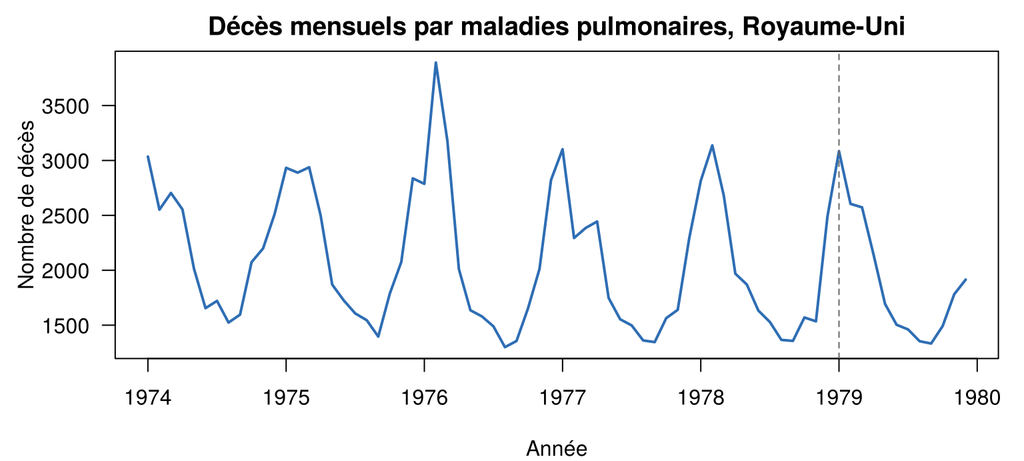

```r
par(mar = c(4, 4.5, 2, 1), las = 1)                       # marges du graphique, étiquettes horizontales
plot(y, lwd = 2, col = "#2E6DB4", xlab = "Année", ylab = "Nombre de décès",
     main = "Décès mensuels par maladies pulmonaires, Royaume-Uni")  # trace la série dans le temps
abline(v = 1979, lty = 2, col = "grey40")                 # trait vertical : début de la période de test
```

**Lecture.** Le même motif revient chaque année : un **pic en hiver** et un **creux en été**. C’est une **saisonnalité de période 12 mois**. Les pics n’ont pas tous la même hauteur : celui de l’hiver 1975-1976 est bien plus haut. Ce sont précisément ces écarts à la saison « normale » qui intéressent la surveillance.

## 2.2 Profil par mois

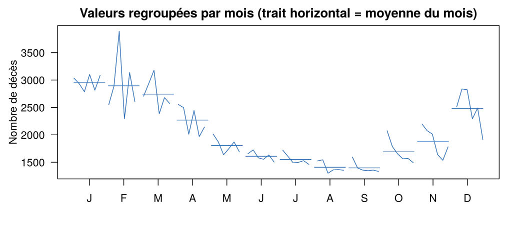

```r
par(mar = c(4, 4.5, 2, 1), las = 1)                       # mêmes réglages graphiques
monthplot(y, col = "#2E6DB4", ylab = "Nombre de décès",
          main = "Valeurs regroupées par mois (trait horizontal = moyenne du mois)")
```

**Lecture.** On compte environ 2 900 décès en janvier-février, contre environ 1 400 de juillet à septembre. **Le mois de l’année explique à lui seul l’essentiel des variations.**

## 2.3 La série est-elle stationnaire ?

**Notion.** Une série est **stationnaire** si ses propriétés statistiques ne changent pas dans le temps : une moyenne constante, une variance constante, et une corrélation entre deux dates qui ne dépend que de leur écart. Les modèles AR, MA et ARMA **exigent** cette propriété.

On la juge **d’abord à l’œil, sur le chronogramme**, en posant trois questions :

| Question | Si la réponse est… | Problème | Remède |
| --- | --- | --- | --- |
| Le niveau moyen reste-t-il constant ? | non | tendance | différencier, ou régresser sur le temps |
| Un motif se répète-t-il à intervalle fixe ? | oui | saison | différence saisonnière, ou harmoniques |
| L’amplitude des oscillations est-elle constante ? | non | variance non constante | logarithme |

Pour `ldeaths`, la deuxième question suffit : **la saison est évidente, donc la série n’est pas stationnaire**. On le confirme avec l’ACF.

## 2.4 Autocorrélations de la série brute

**Notions.**

- L’**ACF** au retard $h$ est la corrélation entre la valeur d’un mois et celle de $h$ mois plus tôt. Elle mêle les liens directs et indirects.
- La **PACF** au retard $h$ est la même corrélation, une fois retiré l’effet des mois intermédiaires. C’est le lien **direct** seulement.
- Les pointillés valent $\pm 2/\sqrt{n}$. Une barre qui les dépasse est significative au seuil d’environ 5 %.

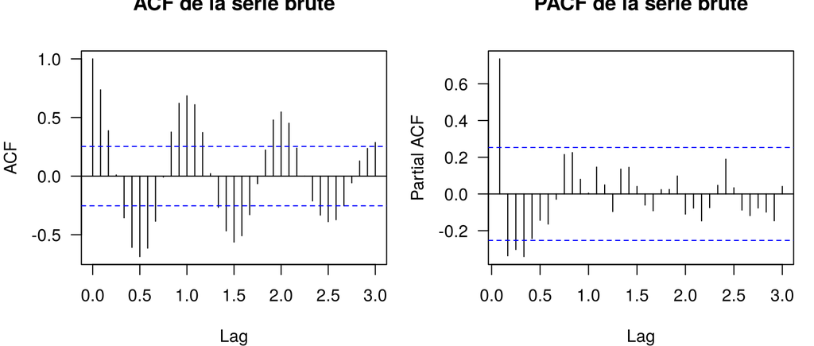

```r
par(mfrow = c(1, 2), mar = c(4, 4, 2.5, 1), las = 1)            # deux graphiques côte à côte
acf(y_train, lag.max = 36, main = "ACF de la série brute")       # corrélation entre y(t) et y(t-h)
pacf(y_train, lag.max = 36, main = "PACF de la série brute")     # corrélation directe au retard h
```

```r
round(acf(y_train, plot = FALSE, lag.max = 12)$acf[-1], 2)       # valeurs de l'ACF, retards 1 à 12
```

```
##  [1]  0.74  0.39  0.01 -0.36 -0.61 -0.69 -0.61 -0.38 -0.01  0.38  0.62  0.68
```

**Lecture de l’axe.** Pour un objet `ts` mensuel, l’axe « Lag » est en **années** : 1,0 correspond à 12 mois et 0,5 à 6 mois.

**Lecture.** L’ACF forme une **vague de période 12** qui décroît très lentement : environ +0,74 à 1 mois, −0,69 à 6 mois, +0,68 à 12 mois. Un mois de janvier ressemble au janvier précédent et pas à un mois de juillet. C’est la signature d’une **série non stationnaire à cause de la saison**. À ce stade, **la PACF n’est pas interprétable** pour choisir un ordre : il faut d’abord traiter la saison.

# 3 Décomposition additive : un plan pour le modèle

## 3.1 Additif ou multiplicatif ? Le choix, preuve à l’appui

**Notion.** On décompose une série en **tendance + saison + reste**. Il existe deux grandes façons d’assembler ces trois morceaux :

- **additive** : $y_t = T_t + S_t + u_t$. La saison **ajoute un nombre fixe** de décès, par exemple +950 en février chaque année ;
- **multiplicative** : $y_t = T_t \times S_t \times u_t$. La saison **ajoute un pourcentage**, par exemple +45 % en février. Dans ce cas, les vagues grandissent quand le niveau monte.

**Le test** : l’amplitude saisonnière (l’écart entre le mois le plus haut et le mois le plus bas d’une année) grandit-elle avec le niveau moyen de l’année ?

```r
annee     <- floor(time(y))                          # l'année de chaque observation
niveau    <- tapply(y, annee, mean)                  # niveau moyen de chaque année
amplitude <- tapply(y, annee, function(v) max(v) - min(v))   # amplitude de chaque année (max - min)
round(cbind(niveau, amplitude, ratio = amplitude / niveau), 2)   # tableau récapitulatif par année
```

```
##       niveau amplitude ratio
## 1974 2178.33      1511  0.69
## 1975 2175.08      1542  0.71
## 1976 2143.17      2591  1.21
## 1977 1935.75      1756  0.91
## 1978 1995.92      1780  0.89
## 1979 1911.50      1751  0.92
```

```r
cor(niveau, amplitude)                               # corrélation entre le niveau et l'amplitude
```

```
## [1] 0.06744166
```

**Lecture.** La corrélation niveau–amplitude vaut 0.07, c’est-à-dire qu’elle est quasi nulle. Entre 1974 et 1979, le niveau baisse d’environ 12 %, alors que l’amplitude ne diminue pas : c’est l’inverse de ce qu’impliquerait un schéma multiplicatif. L’année 1976, atypique, correspond à une épidémie. Une série multiplicative aurait des vagues qui grossissent régulièrement avec le niveau, comme `AirPassengers`. **On retient donc le modèle additif.** Si la série avait été multiplicative, on aurait pris le logarithme, puisque $\log(T\times S\times u)=\log T+\log S+\log u$ redevient additif.

## 3.2 La décomposition

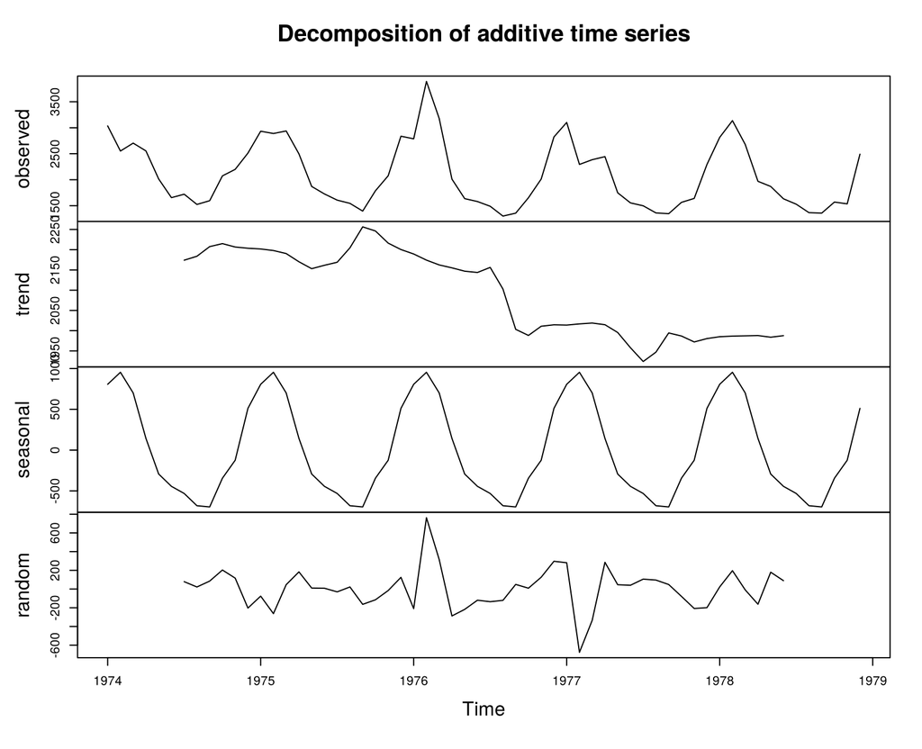

```r
dec <- decompose(y_train)          # décomposition additive (type = "additive" par défaut)
plot(dec)                          # 4 panneaux : observé, tendance, saison, reste
```

```r
round(dec$figure)                  # les 12 coefficients saisonniers (écart au niveau de la tendance)
```

```
##  [1]  807  954  701  143 -294 -444 -532 -682 -697 -344 -124  512
```

## 3.3 Lecture de chaque panneau

**Exemple concret, février 1976.** L’observé vaut 3 891 décès, la tendance 2174, la saison 954 et le reste 763. On vérifie que $2174 + 954 + 763 = 3891$ : la décomposition **découpe chaque valeur en trois morceaux qui s’additionnent**.

**Chaque panneau a sa propre échelle verticale.** La tendance paraît agitée, mais elle ne varie que d’environ 300 décès. La saison varie de plus de 1 600. Il faut toujours lire les chiffres de l’axe avant de comparer deux panneaux.

- **observed** : la série brute, qui sert de point de départ.
- **trend** : pour chaque mois, R fait la moyenne des 12 mois qui l’entourent. Sur une année complète, pics et creux se compensent : la saison disparaît, et il reste le **niveau moyen**. Il faut 6 mois de chaque côté pour faire ce calcul, c’est pourquoi la courbe **commence en juillet 1974 et s’arrête en juin 1978**. Le niveau passe d’environ 2 200 décès par mois à environ 1 980, soit une **baisse lente d’environ 10 %**. La petite bosse fin 1975 – début 1976 vient du pic de février 1976, qui fait monter la moyenne des mois voisins.
- **seasonal** : R retire la tendance, puis fait la moyenne de ce qui reste pour chaque mois. On obtient **12 nombres répétés à l’identique chaque année**, de somme nulle : de -697 (septembre) à +954 (février). La saison **domine** la série : son amplitude est environ 5 fois la variation de la tendance.
- **random** : le reste vaut observé − tendance − saison. On y repère les **anomalies** : +763 en février 1976 (un hiver beaucoup plus meurtrier que la normale), −677 en février 1977 (un hiver calme). Son écart-type vaut environ 218 décès. Il oscille autour de 0 sans motif évident, mais garde une petite mémoire d’un mois à l’autre, qu’on modélisera plus loin.

## 3.4 Ce que la décomposition apporte au modèle

La décomposition ne sert pas directement au calcul : elle sert de **plan**. Elle montre **quels morceaux il faut modéliser** :

| Panneau | Ce qu’il montre | Ce qu’on mettra dans le modèle |
| --- | --- | --- |
| trend | une baisse lente et régulière | une **droite** $a + b\,t$ |
| seasonal | la même vague chaque année | une **vague fixe de période 12** (harmoniques) |
| random | des écarts avec une petite mémoire | un **AR(p)** |

On n’utilise pas directement les chiffres de `decompose()` : sa tendance **s’arrête 6 mois avant la fin** des données et n’a **pas de formule**, donc elle ne se prolonge pas dans le futur. Une droite et une vague, elles, se prolongent sans difficulté.

Il existe d’autres méthodes de décomposition : `stl()`, qui accepte une saison évolutive et résiste aux valeurs extrêmes, et X‑13‑ARIMA‑SEATS, la méthode officielle de l’Insee. Pour une saison stable comme ici, `decompose()` suffit.

# 4 La référence de prévision : le naïf saisonnier

**Principe.** C’est la prévision **la plus simple possible** : pour chaque mois de 1979, on prend la valeur du même mois de 1978. Elle ne demande aucun modèle. **Tout modèle sérieux doit faire mieux.**

```r
prev_naif <- ts(as.numeric(window(y_train, start = c(1978, 1))),   # les 12 valeurs de 1978...
                start = c(1979, 1), frequency = 12)                 # ...recopiées comme prévisions de 1979
rmse <- function(obs, prev) sqrt(mean((obs - prev)^2))              # racine de l'erreur quadratique moyenne
tab_naif <- data.frame(mois = month.abb,                            # tableau de construction
                       val_1978 = as.numeric(prev_naif),
                       obs_1979 = as.numeric(y_test),
                       erreur = as.numeric(y_test - prev_naif))
tab_naif                                                            # affichage
```

```
##    mois val_1978 obs_1979 erreur
## 1   Jan     2815     3084    269
## 2   Feb     3137     2605   -532
## 3   Mar     2679     2573   -106
## 4   Apr     1969     2143    174
## 5   May     1870     1693   -177
## 6   Jun     1633     1504   -129
## 7   Jul     1529     1461    -68
## 8   Aug     1366     1354    -12
## 9   Sep     1357     1333    -24
## 10  Oct     1570     1492    -78
## 11  Nov     1535     1781    246
## 12  Dec     2491     1915   -576
```

```r
rmse(y_test, prev_naif)                                             # RMSE du naïf saisonnier
```

```
## [1] 265.924
```

**Le critère RMSE.** $\text{RMSE}=\sqrt{\frac{1}{h}\sum_{t}(y_t-\widehat y_t)^2}$. Elle s’exprime dans l’unité de la série, ici en **décès**. Plus elle est petite, meilleure est la prévision. Le naïf saisonnier obtient **266 décès** : c’est la **barre à battre**.

# 5 Rappels : les modèles et leur identification

## 5.1 Les modèles de base

Ici, $\varepsilon_t$ est un **choc** imprévisible (bruit blanc) et $B$ est l’opérateur retard : $By_t=y_{t-1}$.

| Modèle | Équation | Ce que ça veut dire |
| --- | --- | --- |
| **AR(p)** | $y_t = \varphi_1 y_{t-1} + \dots + \varphi_p y_{t-p} + \varepsilon_t$ | le présent dépend des $p$ **dernières valeurs** ; un choc s’éteint progressivement |
| **MA(q)** | $y_t = \varepsilon_t + \theta_1\varepsilon_{t-1} + \dots + \theta_q\varepsilon_{t-q}$ | le présent dépend des $q$ **derniers chocs** ; un choc disparaît net après $q$ mois |
| **ARMA(p,q)** | les deux à la fois | mémoire des valeurs et des chocs passés |
| **ARIMA(p,d,q)** | ARMA sur $(1-B)^d y_t$ | pour une série avec tendance : on modélise les variations |
| **SARIMA(p,d,q)(P,D,Q)$_{12}$** | ARIMA + le même mécanisme à l’échelle de 12 mois | pour une série saisonnière |

AR, MA et ARMA supposent une série **stationnaire**. ARIMA et SARIMA la rendent stationnaire par différenciation.

## 5.2 Reconnaître un modèle sur l’ACF et la PACF

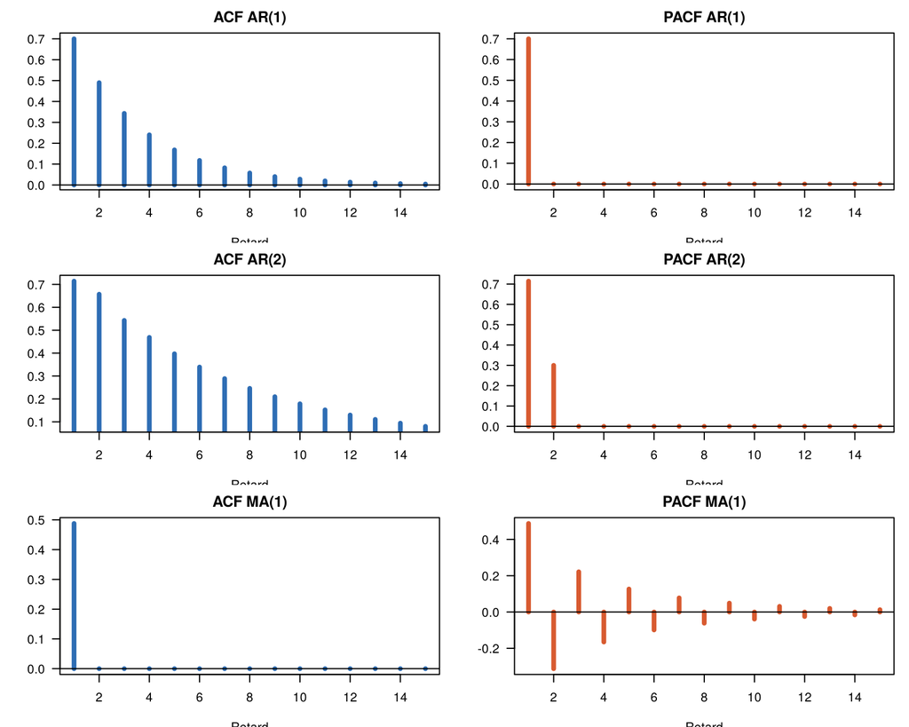

| Ce que tu vois | Modèle |
| --- | --- |
| la **PACF** coupe net au retard $p$, l’ACF décroît | **AR(p)** : la PACF donne $p$ |
| l’**ACF** coupe net au retard $q$, la PACF décroît | **MA(q)** : l’ACF donne $q$ |
| les deux décroissent sans coupure | **ARMA** : on choisit l’ordre par AIC |
| l’ACF décroît très lentement ou forme une vague | **non stationnaire** : il faut traiter la série d’abord |

```r
par(mfrow = c(3, 2), mar = c(3.5, 4, 2.2, 1), las = 1)      # grille de 3 × 2 graphiques
sig <- function(ar = numeric(), ma = numeric(), nom) {      # trace l'ACF et la PACF théoriques d'un modèle
  a <- ARMAacf(ar = ar, ma = ma, lag.max = 15)[-1]          # ACF théorique (on retire le retard 0)
  p <- ARMAacf(ar = ar, ma = ma, lag.max = 15, pacf = TRUE) # PACF théorique
  plot(a, type = "h", lwd = 4, col = "#2E6DB4", main = paste("ACF", nom), xlab = "Retard", ylab = ""); abline(h = 0)
  plot(p, type = "h", lwd = 4, col = "#D85A30", main = paste("PACF", nom), xlab = "Retard", ylab = ""); abline(h = 0)
}
sig(ar = 0.7, nom = "AR(1)")                 # AR(1) : ACF décroissante, PACF coupée après 1
sig(ar = c(0.5, 0.3), nom = "AR(2)")         # AR(2) : PACF coupée après 2
sig(ma = 0.8, nom = "MA(1)")                 # MA(1) : ACF coupée après 1, PACF décroissante
```

**Moyen mnémotechnique** : l’**A**R se lit sur la P**A**CF, le **M**A se lit sur l’ACF. **Méthode** : regarder la série, puis chercher le graphique qui coupe net, puis vérifier que les résidus du modèle estimé forment un bruit blanc.

# 6 Option 1 (rejetée) : un AR directement sur la série brute

On fait volontairement l’erreur de traiter la série comme si elle était stationnaire, pour voir ce qui se passe.

```r
ar_brut <- ar(y_train, aic = TRUE, order.max = 15)      # AR sur la série brute, ordre choisi par AIC (Yule-Walker)
ar_brut$order                                           # ordre retenu
```

```
## [1] 5
```

```r
prev_ar_brut <- predict(ar_brut, n.ahead = h)$pred      # prévisions des 12 mois de 1979
rmse(y_test, prev_ar_brut)                              # RMSE à comparer au naïf saisonnier
```

```
## [1] 316.6115
```

**Lecture.** L’AR(5) obtient une RMSE de **317**, soit **pire que le naïf saisonnier** (266). Un AR(5) ne voit que 5 mois en arrière : il ne peut pas reproduire un cycle de 12 mois, et ses prévisions retombent vers la moyenne globale (environ 2 000).

**Leçon.** On ne peut pas appliquer un AR à une série saisonnière sans traiter d’abord la saison. Deux façons de le faire sont étudiées ci-dessous : **effacer** la saison par différence (SARIMA), ou la **décrire** par une formule (régression harmonique).

# 7 Option 2 (testée) : un modèle SARIMA

## 7.1 Effacer la saison par différence saisonnière

**Idée.** On compare chaque mois au même mois de l’année précédente, $y_t - y_{t-12}$, ce qui fait disparaître la saison. On modélise ensuite ce qui reste, mois par mois et année par année.

```r
d12 <- diff(y_train, lag = 12)                                     # différence saisonnière y(t) - y(t-12)
length(d12)                                                        # on perd la première année : 48 mois restent
```

```
## [1] 48
```

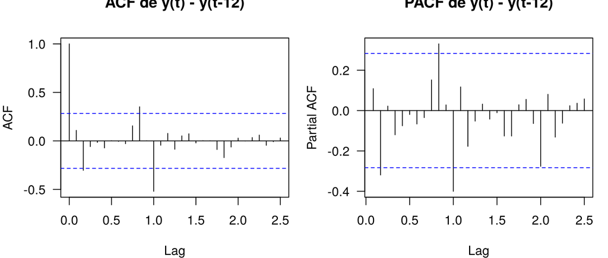

```r
par(mfrow = c(1, 2), mar = c(4, 4, 2.5, 1), las = 1)
acf(d12, lag.max = 30, main = "ACF de y(t) - y(t-12)")             # la vague a disparu
pacf(d12, lag.max = 30, main = "PACF de y(t) - y(t-12)")           # pics aux retards 2 et 12
```

## 7.2 Comparer plusieurs candidats

```r
candidats <- list(c(0,0,2,0,1,1), c(1,0,0,0,1,1), c(1,0,0,1,1,0), c(2,0,0,1,1,0))   # (p,d,q,P,D,Q)
res <- t(sapply(candidats, function(m) {                                            # pour chaque candidat
  f <- arima(y_train, order = m[1:3], seasonal = list(order = m[4:6], period = 12), method = "ML")  # estimation
  p <- predict(f, n.ahead = h)                                                      # prévision de 1979
  k <- sum(m[c(1, 3, 4, 6)])                                                        # nombre de paramètres ARMA
  c(AIC  = AIC(f),                                                                  # critère d'information
    RMSE = rmse(y_test, p$pred),                                                    # erreur de prévision hors échantillon
    LjungBox_p = Box.test(residuals(f), lag = 24, type = "Ljung", fitdf = k)$p.value)  # résidus = bruit blanc ?
}))
rownames(res) <- sapply(candidats, function(m)                                      # noms lisibles des modèles
  sprintf("SARIMA(%d,%d,%d)(%d,%d,%d)12", m[1], m[2], m[3], m[4], m[5], m[6]))
round(res, 2)                                                                       # tableau de comparaison
```

```
##                           AIC   RMSE LjungBox_p
## SARIMA(0,0,2)(0,1,1)12 690.24 260.82       0.92
## SARIMA(1,0,0)(0,1,1)12 691.33 258.52       0.69
## SARIMA(1,0,0)(1,1,0)12 697.15 163.38       0.48
## SARIMA(2,0,0)(1,1,0)12 695.61 161.75       0.71
```

**Lecture et piège important.**

1. Tous les candidats ont des résidus qui forment un bruit blanc (p > 0,05).
2. Le modèle de **meilleur AIC** (SARIMA(0,0,2)(0,1,1)$_{12}$) **prévoit mal 1979** : sa RMSE est à peine meilleure que celle du naïf saisonnier. **L’AIC mesure l’ajustement au passé, pas la qualité de la prévision** : c’est pour cela qu’on garde une année de test.
3. Le meilleur SARIMA en prévision, **SARIMA(2,0,0)(1,1,0)$_{12}$**, atteint une RMSE de **162**.
4. Ce choix est fragile : la différence saisonnière fait perdre une année, et il ne reste que 48 mois pour estimer.

# 8 Option 3 (retenue) : régression harmonique avec erreurs AR(2)

## 8.1 Étape 1 : la régression que tu connais

Une droite dans le temps :
$$y_t = a +
b\,t + \varepsilon_t,$$
où $t$ est le numéro du mois (1 pour janvier 1974, …, 60 pour décembre 1978), et **$a$, $b$ sont 2 constantes à estimer par moindres carrés**. Problème : une droite ne peut pas monter en hiver et descendre en été. Il faut d’autres variables explicatives.

## 8.2 Étape 2 : quatre variables explicatives calculées à partir de $t$

On crée 4 colonnes, **calculées à partir de $t$** :

- $x_1=\cos(2\pi t/12)$ et $x_2=\sin(2\pi t/12)$ : une vague de période 12 mois ;
- $x_3=\cos(2\pi t/6)$ et $x_4=\sin(2\pi t/6)$ : une vague de période 6 mois, qui corrige la forme de la première.

```r
harmoniques <- function(tt, K) {                    # fabrique les colonnes cos/sin pour les temps tt
  M <- NULL                                         # matrice vide au départ
  for (k in 1:K) M <- cbind(M, cos(2 * pi * k * tt / 12), sin(2 * pi * k * tt / 12))  # une paire par vague
  colnames(M) <- paste0(rep(c("x_cos", "x_sin"), K), rep(1:K, each = 2))               # noms lisibles
  M                                                 # on renvoie la matrice
}
t_train <- 1:n_train                                # temps 1 à 60 (apprentissage)
t_test  <- (n_train + 1):(n_train + h)              # temps 61 à 72 (1979)
tab <- data.frame(t = t_train, mois = rep(month.abb, 5), y = as.numeric(y_train),
                  round(harmoniques(t_train, 2), 2))   # le tableau de données de la régression
tab[c(1:3, 12:13), ]                                # lignes de janvier, février, mars, décembre 1974 et janvier 1975
```

```
##     t mois    y x_cos1 x_sin1 x_cos2 x_sin2
## 1   1  Jan 3035   0.87   0.50    0.5   0.87
## 2   2  Feb 2552   0.50   0.87   -0.5   0.87
## 3   3  Mar 2704   0.00   1.00   -1.0   0.00
## 12 12  Dec 2512   1.00   0.00    1.0   0.00
## 13 13  Jan 2933   0.87   0.50    0.5   0.87
```

**La seule chose à retenir :** les valeurs de $x_1, x_2, x_3, x_4$ **se répètent tous les 12 mois**. Janvier 1975 (t = 13) a exactement les mêmes valeurs que janvier 1974 (t = 1). Ces colonnes servent donc d’**étiquette du mois de l’année**, comme des indicatrices de mois, mais avec beaucoup moins de colonnes.

## 8.3 Étape 3 : une régression linéaire multiple ordinaire

$$y_t = a + b\,t + c_1x_1 + c_2x_2 +
c_3x_3 + c_4x_4 + \varepsilon_t .$$

C’est exactement comme une régression du type salaire = a + b·âge + c·diplôme. Il y a **6 constantes à estimer** : $a, b, c_1, c_2, c_3, c_4$, par **moindres carrés**.

## 8.4 Choisir le nombre de vagues K

Chaque vague ajoute 2 colonnes. On compare $K = 1, 2, 3$ par l’AIC.

```r
choix_K <- t(sapply(1:3, function(K) {                            # pour K = 1, 2, 3
  f <- lm(y_train ~ t_train + harmoniques(t_train, K))            # régression par moindres carrés
  c(K = K, nb_coef = 2 + 2 * K, AIC = AIC(f), R2_ajuste = summary(f)$adj.r.squared)
}))
round(choix_K, 3)                                                 # tableau de comparaison
```

```
##      K nb_coef     AIC R2_ajuste
## [1,] 1       4 842.508     0.825
## [2,] 2       6 833.764     0.854
## [3,] 3       8 837.603     0.848
```

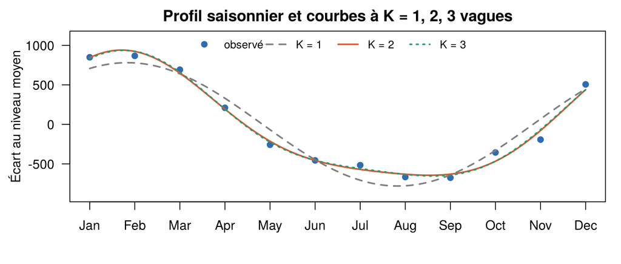

```r
prof <- tapply(y_train - mean(y_train), cycle(y_train), mean)     # profil saisonnier moyen observé
mm <- seq(1, 12, by = 0.05)                                       # grille fine pour tracer des courbes lisses
par(mar = c(4, 4.5, 2, 1), las = 1)
plot(1:12, prof, pch = 19, col = "#2E6DB4", xaxt = "n", ylim = c(-900, 1100), xlab = "",
     ylab = "Écart au niveau moyen", main = "Profil saisonnier et courbes à K = 1, 2, 3 vagues")
axis(1, 1:12, month.abb)                                          # mois en abscisse
cols <- c("grey50", "#D85A30", "#1D9E75")
for (K in 1:3) {                                                  # ajuste le profil avec K vagues et trace la courbe
  cf <- coef(lm(prof ~ harmoniques(1:12, K)))
  lines(mm, cbind(1, harmoniques(mm, K)) %*% cf, col = cols[K], lwd = 2, lty = c(2, 1, 3)[K])
}
legend("top", c("observé", "K = 1", "K = 2", "K = 3"), pch = c(19, NA, NA, NA), lty = c(NA, 2, 1, 3),
       col = c("#2E6DB4", cols), lwd = 2, bty = "n", horiz = TRUE, cex = 0.85)
```

**Lecture.** Avec **K = 1**, la forme générale est bonne, mais le pic de février est sous-estimé et le creux d’été trop arrondi. Avec **K = 2**, le pic pointu de l’hiver et le long creux plat de l’été sont bien rendus, et **l’AIC est minimal**. Avec **K = 3**, le gain est trop faible pour 2 paramètres de plus : l’AIC remonte. **On retient K = 2.** (Avec K = 6, la courbe passerait par les 12 points, ce qui équivaut à 11 indicatrices de mois : aucune économie.)

## 8.5 Estimation et lecture des coefficients

```r
K <- 2                                                           # nombre de vagues retenu
reg <- lm(y_train ~ t_train + harmoniques(t_train, K))           # régression : droite + 2 vagues
summary(reg)                                                     # tableau des coefficients
```

```
##
## Call:
## lm(formula = y_train ~ t_train + harmoniques(t_train, K))
##
## Residuals:
##     Min      1Q  Median      3Q     Max
## -654.16 -103.73    5.85  102.53  883.61
##
## Coefficients:
##                               Estimate Std. Error t value Pr(>|t|)
## (Intercept)                   2236.193     62.540  35.756  < 2e-16 ***
## t_train                         -4.936      1.790  -2.757  0.00793 **
## harmoniques(t_train, K)x_cos1  452.358     43.180  10.476 1.28e-14 ***
## harmoniques(t_train, K)x_sin1  620.698     43.657  14.218  < 2e-16 ***
## harmoniques(t_train, K)x_cos2   -3.881     43.180  -0.090  0.92872
## harmoniques(t_train, K)x_sin2  154.581     43.254   3.574  0.00075 ***
## ---
## Signif. codes:  0 '***' 0.001 '**' 0.01 '*' 0.05 '.' 0.1 ' ' 1
##
## Residual standard error: 236.3 on 54 degrees of freedom
## Multiple R-squared:  0.866,  Adjusted R-squared:  0.8536
## F-statistic: 69.79 on 5 and 54 DF,  p-value: < 2.2e-16
```

$$\widehat y_t = 2236 -4.9\,t + 452\,x_1 +
621\,x_2 -4\,x_3 + 155\,x_4$$

- **a = 2236** est le niveau de départ, une fois la saison retirée. **b = -4.9** (p = 0,008) indique que les décès baissent d’environ 5 par mois, soit 60 par an.
- **$c_1$, $c_2$** sont très significatifs : c’est la vague annuelle, d’amplitude $\sqrt{c_1^2+c_2^2}\approx 768$ décès, avec un pic début février.
- **$c_4$** est significatif : c’est la correction qui rend le pic d’hiver pointu. **$c_3$** ne l’est pas, mais on garde la paire complète, car un cosinus et un sinus de même période forment une seule vague.
- **R² ajusté = 0.85** : la tendance et la saison expliquent 85 % des variations.

## 8.6 On utilise la formule comme n’importe quelle régression

```r
x_fev74 <- harmoniques(2, K)                                     # colonnes x pour février 1974 (t = 2)
sum(cr * c(1, 2, x_fev74))                                       # valeur prédite pour février 1974
```

```
## [1] 3125.852
```

```r
x_jan79 <- harmoniques(61, K)                                    # colonnes x pour janvier 1979 (t = 61)
sum(cr * c(1, 61, x_jan79))                                      # prévision (partie régression) de janvier 1979
```

```
## [1] 2769.141
```

Pour prévoir un mois futur, **il suffit de connaître $t$** : les colonnes $x$ se calculent d’avance, et la droite se prolonge. C’est ce qui rend ce modèle facile à utiliser pour la prévision et pour la surveillance.

## 8.7 Les erreurs de la régression sont-elles indépendantes ?

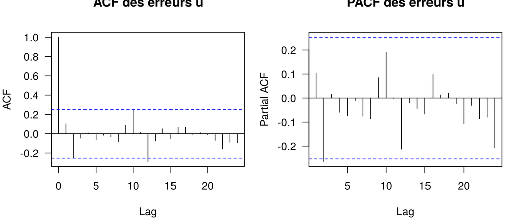

```r
u <- resid(reg)                                                  # u(t) = écart à la saison normale
par(mfrow = c(1, 2), mar = c(4, 4, 2.5, 1), las = 1)
acf(u, lag.max = 24, main = "ACF des erreurs u")                 # la vague a-t-elle disparu ?
pacf(u, lag.max = 24, main = "PACF des erreurs u")               # reste-t-il un lien direct ?
```

```r
round(pacf(u, plot = FALSE, lag.max = 6)$acf[, 1, 1], 2)         # PACF aux retards 1 à 6
```

```
## [1]  0.10 -0.26  0.02 -0.06 -0.07 -0.01
```

```r
2 / sqrt(n_train)                                                # bande de significativité
```

```
## [1] 0.2581989
```

**Lecture (méthode du quiz).** La vague a disparu : la saison est bien retirée, et $u$ est stationnaire. La PACF vaut −0,26 au retard 2, juste à la limite de la bande (0,26), puis plus rien : c’est l’empreinte d’un **AR(2)**. Les erreurs gardent une petite mémoire : quand un mois est anormalement haut, le mois situé deux mois plus tard tend à être un peu plus bas.

**Pourquoi ne pas s’arrêter là ?** Des erreurs autocorrélées rendent les écarts-types des MCO **faux**, donc les tests aussi. De plus, cette mémoire est une information utile **pour prévoir**.

## 8.8 Estimation conjointe : régression + AR(p) sur les erreurs

$$y_t = a + b\,t +
c_1x_1+c_2x_2+c_3x_3+c_4x_4 + u_t,\qquad
u_t=\varphi_1u_{t-1}+\varphi_2u_{t-2}+\varepsilon_t .$$

On estime **les 8 constantes en même temps** par maximum de vraisemblance, avec `arima()` et l’argument `xreg` (les régresseurs).

```r
X_train <- cbind(t = t_train, harmoniques(t_train, K))           # régresseurs de l'apprentissage
X_test  <- cbind(t = t_test,  harmoniques(t_test,  K))           # régresseurs de 1979 (connus d'avance)
choix_p <- t(sapply(0:3, function(p) {                           # pour p = 0, 1, 2, 3
  f <- arima(y_train, order = c(p, 0, 0), xreg = X_train, method = "ML")   # régression + AR(p)
  c(p = p, AIC = AIC(f), BIC = BIC(f))
}))
round(choix_p, 1)                                                # comparaison des ordres
```

```
##      p   AIC   BIC
## [1,] 0 833.8 848.4
## [2,] 1 835.1 851.9
## [3,] 2 832.0 850.8
## [4,] 3 833.9 854.9
```

L’AIC est minimal pour **p = 2**. Le BIC, plus sévère, hésite avec p = 0. On retient p = 2 pour trois raisons : c’est le minimum de l’AIC, c’est cohérent avec la PACF, et le coefficient $\varphi_2$ est significatif.

```r
modele <- arima(y_train, order = c(2, 0, 0), xreg = X_train, method = "ML")   # modèle final
z <- coef(modele) / sqrt(diag(modele$var.coef))                  # statistiques z = estimation / écart-type
round(cbind(coef = coef(modele), se = sqrt(diag(modele$var.coef)), z = z), 2)  # |z| > 1,96 : significatif
```

```
##              coef    se     z
## ar1          0.14  0.12  1.11
## ar2         -0.31  0.13 -2.33
## intercept 2244.98 48.97 45.84
## t           -5.09  1.40 -3.62
## x_cos1     461.65 37.41 12.34
## x_sin1     621.67 37.23 16.70
## x_cos2       7.80 49.46  0.16
## x_sin2     158.13 49.03  3.23
```

```r
Mod(polyroot(c(1, -coef(modele)[c("ar1", "ar2")])))              # stationnarité : racines de 1 - phi1 z - phi2 z^2
```

```
## [1] 1.791074 1.791074
```

**Lecture.**

- **$\varphi_1$ = 0.14** n’est pas significatif. **$\varphi_2$ = -0.31** est significatif (|z| ≈ 2.3). Une explication plausible est l’**effet de moisson** : après un pic, une partie des personnes les plus fragiles est déjà décédée.
- Les racines du polynôme AR ont un module de **1.79 > 1** : la partie AR est **stationnaire**.
- L’écart-type des chocs imprévisibles vaut $\widehat\sigma\approx 213$ décès.

**Le décompte des paramètres :**

| Partie | Constantes | Nombre |
| --- | --- | --- |
| Droite | $a$, $b$ | 2 |
| Saison | $c_1, c_2, c_3, c_4$ | 4 |
| **Régression seule** |  | **6** |
| Erreurs AR(2) | $\varphi_1, \varphi_2$ | 2 |
| **Modèle final** |  | **8** |

# 9 Validation du modèle retenu

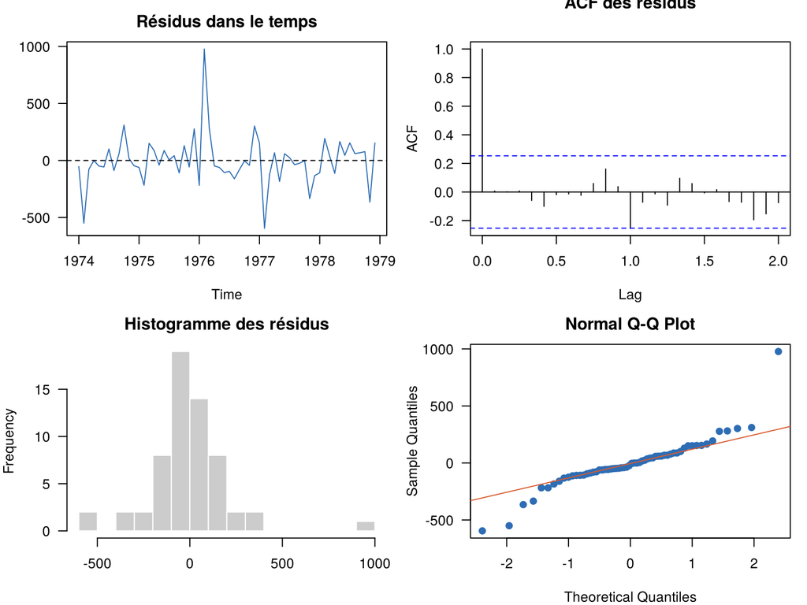

```r
e <- resid(modele)                                               # résidus = chocs imprévisibles estimés
par(mfrow = c(2, 2), mar = c(4, 4, 2.5, 1), las = 1)
plot(e, main = "Résidus dans le temps", ylab = "", col = "#2E6DB4"); abline(h = 0, lty = 2)  # centrés ? motif ?
acf(e, lag.max = 24, main = "ACF des résidus")                   # toutes les barres dans la bande ?
hist(e, breaks = 15, main = "Histogramme des résidus", xlab = "", col = "grey80", border = "white")
qqnorm(e, pch = 19, col = "#2E6DB4"); qqline(e, col = "#D85A30") # comparaison à la loi normale
```

```r
lb <- Box.test(e, lag = 24, type = "Ljung-Box", fitdf = 2)       # H0 : pas d'autocorrélation (retards 1 à 24)
sw <- shapiro.test(e)                                            # H0 : les résidus suivent une loi normale
c(LjungBox_p = lb$p.value, Shapiro_p = sw$p.value)               # p-valeurs des deux tests
```

```
##   LjungBox_p    Shapiro_p
## 7.012087e-01 9.113840e-06
```

**Lecture.**

- **Ljung-Box** : p = 0.7 > 0,05. On ne rejette pas $H_0$ : les résidus sont un **bruit blanc**, et le modèle a capté toute la dépendance temporelle.
- **Shapiro-Wilk** : p ≈ 9.1^{-6}. La **normalité est rejetée**, à cause de quelques mois extrêmes (février 1976 surtout), visibles en haut à droite du QQ-plot. Les coefficients restent valables, mais les intervalles de prévision, qui supposent la normalité, sont **approximatifs**. C’est une limite à signaler.

# 10 Prévision de 1979 et comparaison de tous les modèles

```r
pr <- predict(modele, n.ahead = h, newxreg = X_test)             # prévision : moyenne + écart-type
prev <- pr$pred                                                  # prévision ponctuelle
inf95 <- prev - 1.96 * pr$se                                     # borne basse de l'intervalle à 95 %
sup95 <- prev + 1.96 * pr$se                                     # borne haute de l'intervalle à 95 %
data.frame(mois = month.abb, observe = as.numeric(y_test), prevu = round(as.numeric(prev)),
           inf95 = round(as.numeric(inf95)), sup95 = round(as.numeric(sup95)))   # tableau récapitulatif
```

```
##    mois observe prevu inf95 sup95
## 1   Jan    3084  2911  2493  3329
## 2   Feb    2605  2823  2402  3245
## 3   Mar    2573  2498  2059  2937
## 4   Apr    2143  2083  1643  2524
## 5   May    1693  1704  1263  2146
## 6   Jun    1504  1458  1016  1900
## 7   Jul    1461  1331   889  1773
## 8   Aug    1354  1262   819  1704
## 9   Sep    1333  1265   823  1708
## 10  Oct    1492  1441   999  1883
## 11  Nov    1781  1839  1397  2282
## 12  Dec    1915  2348  1906  2790
```

```r
couverture <- mean(y_test >= inf95 & y_test <= sup95)            # part des mois observés dans l'intervalle
couverture
```

```
## [1] 1
```

```r
comparaison <- c("Naïf saisonnier"               = rmse(y_test, prev_naif),
                 "Option 1 : AR brut"            = rmse(y_test, prev_ar_brut),
                 "Option 2 : SARIMA (meilleur AIC)" = res[1, "RMSE"],
                 "Option 2 : SARIMA (meilleure RMSE)" = res[4, "RMSE"],
                 "Option 3 : harmoniques + AR(2)" = rmse(y_test, prev))
round(sort(comparaison))                                         # du meilleur au moins bon
```

```
##     Option 3 : harmoniques + AR(2) Option 2 : SARIMA (meilleure RMSE)
##                                161                                162
##   Option 2 : SARIMA (meilleur AIC)                    Naïf saisonnier
##                                261                                266
##                 Option 1 : AR brut
##                                317
```

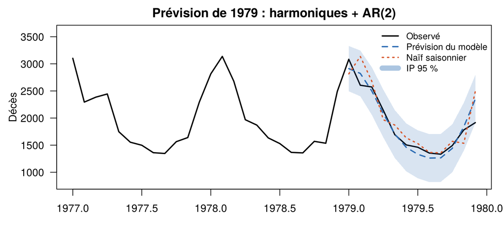

```r
par(mar = c(3, 4.5, 2, 1), las = 1)
plot(window(y, start = c(1977, 1)), ylim = c(800, 3600), lwd = 2, xlab = "", ylab = "Décès",
     main = "Prévision de 1979 : harmoniques + AR(2)")           # série observée 1977-1979
polygon(c(time(prev), rev(time(prev))), c(inf95, rev(sup95)),
        col = rgb(0.18, 0.43, 0.71, 0.18), border = NA)          # bande de l'intervalle à 95 %
lines(prev, col = "#2E6DB4", lwd = 2, lty = 2)                   # prévision du modèle retenu
lines(prev_naif, col = "#D85A30", lwd = 2, lty = 3)              # référence naïve
legend("topright", c("Observé", "Prévision du modèle", "Naïf saisonnier", "IP 95 %"),
       col = c("black", "#2E6DB4", "#D85A30", rgb(0.18, 0.43, 0.71, 0.4)),
       lty = c(1, 2, 3, 1), lwd = c(2, 2, 2, 8), bty = "n", cex = 0.85)
```

**Lecture.**

- Le modèle retenu atteint une **RMSE de 161 décès**, contre 266 pour le naïf saisonnier : l’erreur baisse d’environ **39 %**.
- **100 %** des mois de 1979 tombent dans l’intervalle à 95 %. Décembre 1979 frôle la borne basse : c’est un mois de décembre inhabituellement calme.
- Le meilleur SARIMA prévoit **aussi bien** (162). Les deux approches se valent en précision.

## 10.1 Pourquoi retenir l’option 3 plutôt que le SARIMA ?

| Critère | SARIMA | Harmoniques + AR(2) |
| --- | --- | --- |
| Précision sur 1979 | RMSE 162 | RMSE 161 |
| Traitement de la saison | effacée par différence (perte d’un an de données) | décrite par une formule, sur toutes les données |
| Stabilité du choix | fragile : le meilleur AIC prévoit mal | stable : l’AIC, la PACF et les tests concordent |
| Niveau « attendu » pour chaque mois | non | **oui** : la partie a + bt + saison |
| Lien avec la surveillance | indirect | **direct : c’est la base du modèle de Serfling** |

Les deux modèles prévoient aussi bien. L’option 3 est retenue parce qu’elle fournit un **niveau de référence interprétable**, exactement ce dont la surveillance a besoin pour définir une hausse anormale. Le SARIMA serait préférable si la saison **changeait d’une année à l’autre**, ou si la série était longue.

# 11 Modèle de Serfling et seuil épidémique

## 11.1 Principe

Le modèle de **Serfling (1963)** sert à détecter les excès de mortalité, notamment grippale. Il reprend la régression de l’option 3, en plus simple :

1. le **niveau de base attendu** est une droite plus **une seule** vague annuelle : $y_t=a+bt+\alpha\cos(2\pi t/12)+\beta\sin(2\pi t/12)+\varepsilon_t$, sans terme AR ;
2. on l’estime **en excluant les mois épidémiques**, pour qu’il représente une année « normale » ;
3. le **seuil épidémique** est la **borne supérieure de l’intervalle de prévision à 95 %**. Un mois au-dessus déclenche une **alerte**, et l’**excès** vaut observé − attendu.

## 11.2 Algorithme

```r
t_all <- 1:length(y)                                             # temps 1 à 72 (toute la série)
base <- data.frame(y = as.numeric(y), t = t_all,                 # tableau de travail
                   cos1 = cos(2 * pi * t_all / 12),              # vague annuelle : cosinus
                   sin1 = sin(2 * pi * t_all / 12))              # vague annuelle : sinus
s1 <- lm(y ~ t + cos1 + sin1, data = base)                       # étape 1 : ajustement sur toute la série
seuil1 <- predict(s1, newdata = base, interval = "prediction", level = 0.95)[, "upr"]  # seuil provisoire
garder <- base$y <= seuil1                                       # on exclut les mois au-dessus du seuil
sum(!garder)                                                     # nombre de mois exclus
```

```
## [1] 1
```

```r
serfling <- lm(y ~ t + cos1 + sin1, data = base[garder, ])       # étape 2 : base « non épidémique »
round(summary(serfling)$coefficients, 2)                         # coefficients du niveau de base
```

```
##             Estimate Std. Error t value Pr(>|t|)
## (Intercept)  2225.81      52.57   42.34        0
## t              -5.04       1.25   -4.04        0
## cos1          423.89      36.52   11.61        0
## sin1          589.46      37.02   15.92        0
```

```r
ip <- predict(serfling, newdata = base, interval = "prediction", level = 0.95)   # attendu et bornes
base$attendu <- ip[, "fit"]                                      # décès attendus hors épidémie
base$seuil   <- ip[, "upr"]                                      # seuil épidémique
base$alerte  <- base$y > base$seuil                              # TRUE = mois en excès
base$exces   <- ifelse(base$alerte, base$y - base$attendu, 0)    # nombre de décès en excès
base$date    <- format(as.Date(paste(floor(time(y)), cycle(y), 1, sep = "-")), "%Y-%m")   # date lisible
alertes <- base[base$alerte, c("date", "y", "attendu", "seuil", "exces")]                 # mois en alerte
alertes[, -1] <- round(alertes[, -1])                            # arrondi pour l'affichage
alertes
```

```
##       date    y attendu seuil exces
## 26 1976-02 3891    2817  3262  1074
## 27 1976-03 3179    2679  3124   500
## 61 1979-01 3084    2580  3029   504
```

```r
sum(base$exces)                                                  # total des décès en excès
```

```
## [1] 2077.843
```

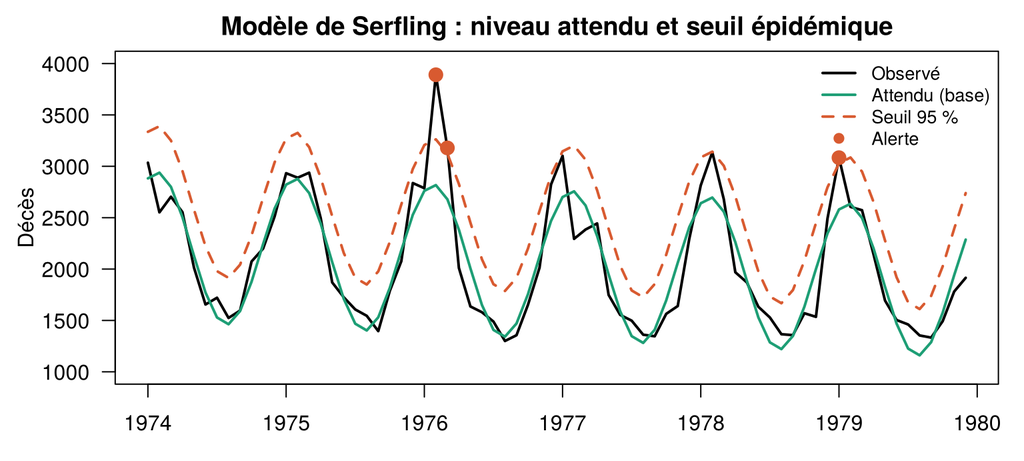

```r
par(mar = c(3, 4.5, 2, 1), las = 1)
plot(y, lwd = 2, ylim = c(1000, 4000), xlab = "", ylab = "Décès",
     main = "Modèle de Serfling : niveau attendu et seuil épidémique")   # série observée
lines(ts(base$attendu, start = c(1974, 1), frequency = 12), col = "#1D9E75", lwd = 2)       # attendu
lines(ts(base$seuil, start = c(1974, 1), frequency = 12), col = "#D85A30", lwd = 2, lty = 2) # seuil
points(time(y)[base$alerte], base$y[base$alerte], pch = 19, col = "#D85A30", cex = 1.4)      # alertes
legend("topright", c("Observé", "Attendu (base)", "Seuil 95 %", "Alerte"),
       col = c("black", "#1D9E75", "#D85A30", "#D85A30"), lty = c(1, 1, 2, NA),
       pch = c(NA, NA, NA, 19), lwd = 2, bty = "n", cex = 0.85)
```

**Lecture.** Un seul mois est exclu à l’étape 1 (février 1976). Le niveau de base garde une tendance d’environ −5 décès par mois et une vague annuelle très significative. On obtient **3 alertes** : février 1976 (environ +1 074 décès en excès), mars 1976 (environ +500) et janvier 1979 (environ +504), soit environ **2078 décès en excès** au total. L’hiver 1975-1976 ressort clairement. Il s’agit probablement d’une épidémie de grippe, mais c’est une **hypothèse à vérifier dans la littérature** avant de l’affirmer.

# 12 Conclusion, limites et préparation de l’entretien

## 12.1 Ce que montre le projet

1. La série est dominée par une **saisonnalité annuelle stable** : le schéma est additif, ce que confirme l’analyse des amplitudes.
2. Un AR appliqué à la série brute **échoue** : il fait moins bien que la simple reprise des valeurs de l’année précédente.
3. Deux façons de traiter la saison prévoient aussi bien l’une que l’autre : le **SARIMA** et la **régression harmonique avec erreurs AR(2)**. Elles réduisent d’environ 40 % l’erreur de prévision par rapport au naïf saisonnier.
4. On retient la régression harmonique parce qu’elle fournit un **niveau attendu**, base du **modèle de Serfling**, qui détecte les mois en excès.

## 12.2 Limites

- Les résidus **ne sont pas gaussiens** : les intervalles sont approximatifs. Pistes : un modèle de Poisson ou binomial négatif (des comptages de décès), ou des intervalles par bootstrap.
- La série est **courte** : 6 ans, dont 5 pour estimer.
- La saison est supposée **identique chaque année**.
- Le seuil de Serfling dépend des mois exclus. En pratique, on exclut les périodes grippales repérées par des données virologiques.

## 12.3 Phrase pour la lettre de motivation

> Dans un travail personnel, j’ai modélisé les décès mensuels par maladies pulmonaires au Royaume-Uni par une régression harmonique à erreurs autorégressives AR(2), réduisant d’environ 40 % l’erreur de prévision (RMSE) par rapport à une référence saisonnière, puis mis en œuvre un modèle de Serfling pour détecter les excès de mortalité.

## 12.4 Questions probables en entretien

| Question | Réponse courte |
| --- | --- |
| Pourquoi un AR seul ne suffit-il pas ? | La série n’est pas stationnaire à cause de la saison ; un AR(5) brut fait pire que le naïf (RMSE 317 contre 266). |
| Additif ou multiplicatif ? | Additif : l’amplitude saisonnière ne grandit pas avec le niveau. |
| Pourquoi des cosinus et des sinus ? | Ils décrivent une saison fixe avec peu de paramètres ; on en garde 2 vagues (K = 2, AIC minimal). |
| Pourquoi p = 2 ? | La PACF des erreurs coupe au retard 2, l’AIC est minimal, et $\varphi_2$ est significatif. |
| Comment le modèle est-il validé ? | Résidus en bruit blanc (Ljung-Box, p = 0,70) ; limite : normalité rejetée. |
| Pourquoi pas un SARIMA ? | Testé : même précision, mais choix plus fragile et pas de niveau attendu interprétable. |
| Comment fonctionne le Serfling ? | Base = droite + vague annuelle hors épidémie ; seuil = borne haute à 95 % ; 3 alertes, dont l’hiver 1975-76. |

## 12.5 Prochaine étape

Un projet sur les **données de panel** : plusieurs individus (par exemple des régions ou des pays) suivis à plusieurs dates.